# Vocabulary ICC and power for the border cohort

This document estimates how much of the variation in LEVANTE Vocabulary scores is stable between children of the same age (the ICC), and uses it to calculate power for a three-wave longitudinal study relating an environmental index to the growth of Vocabulary scores.

What comes from data and what is assumed:

| Quantity | Source |
| --- | --- |
| ICC of Vocabulary scores at a fixed age | Estimated here, from LEVANTE pilot data (Leipzig) |
| Within-age SD of Vocabulary scores | Estimated here |
| Average yearly growth in Vocabulary scores | Estimated here |
| Target effect, β = .08 SD/year | Chosen (proposal) |
| Between-child SD of growth rates, .15 SD/year | Assumed |
| Three annual waves, 20% attrition by wave 3, α = .05 | Design assumptions |

```r
library(dplyr)
library(readr)
library(ggplot2)
library(lme4)
library(simr)

# fix the random seed so bootstrap intervals are identical on every run
seed <- 20260914
set.seed(seed)
cat("Random seed:", seed, "\n")
```

```
## Random seed: 20260914
```

# Data

## Download

The scores table comes from the public LEVANTE pilot release on Redivis (`levante_data_pilots`, current version). Access needs a Redivis account, the signed LEVANTE data use agreement, and an API token with the `data.data` scope saved in `~/.Renviron` as `REDIVIS_API_TOKEN`. This chunk only runs if `data/scores.csv` is not already saved.

```r
# qualified Redivis reference: owner.dataset:id:version.table:id
table_ref <- "levante.levante_data_pilots:68kn:current.scores:pgms"
url <- paste0("https://redivis.com/api/v1/tables/", table_ref, "/rows?format=csv")

token <- Sys.getenv("REDIVIS_API_TOKEN")
if (token == "") stop("Set REDIVIS_API_TOKEN in ~/.Renviron and restart R.")

# build the request, attach the token, and write the response straight to a CSV file
dir.create("data", showWarnings = FALSE)
httr2::request(url) |>
  httr2::req_headers(Authorization = paste("Bearer", token)) |>
  httr2::req_perform(path = "data/scores.csv")
```

## Load and filter

```r
# read the full scores table (all tasks, all pilot sites)
scores <- read_csv("data/scores.csv", show_col_types = FALSE)

# record which data this document was run on
cat("File downloaded:", format(file.mtime("data/scores.csv"), "%Y-%m-%d"), "\n")
```

```
## File downloaded: 2026-09-14
```

```r
cat("Rows in scores table:", nrow(scores), "\n")
```

```
## Rows in scores table: 21335
```

```r
# keep Vocabulary runs, then runs without an exclusion flag, then runs with a score
vocab_all    <- filter(scores, task_id == "vocab")
vocab_scored <- filter(vocab_all, is.na(exclusion))
vocab        <- filter(vocab_scored, !is.na(score))

# how many runs survive each step
tibble(step = c("Vocabulary runs", "no exclusion flag", "has a score"),
       runs = c(nrow(vocab_all), nrow(vocab_scored), nrow(vocab)))
```

```
## # A tibble: 3 × 2
##   step               runs
##   <chr>             <int>
## 1 Vocabulary runs    1658
## 2 no exclusion flag  1391
## 3 has a score        1391
```

```r
# reasons runs were excluded
count(vocab_all, exclusion)
```

```
## # A tibble: 5 × 2
##   exclusion            n
##   <chr>            <int>
## 1 duplicate           19
## 2 few_valid_trials    60
## 3 incomplete          45
## 4 no_data            143
## 5 <NA>              1391
```

## Which sites have children tested more than once?

```r
# one row per child: number of scores and age at first test
kids <- vocab |>
  group_by(dataset, user_id) |>
  summarise(n_scores = n(), first_age = min(age), .groups = "drop")

# per site: children, retested children, missing ages, and age range at first test
kids |>
  group_by(dataset) |>
  summarise(children = n(),
            retested = sum(n_scores >= 2),
            missing_age = sum(is.na(first_age)),
            youngest = round(min(first_age, na.rm = TRUE), 1),
            oldest = round(max(first_age, na.rm = TRUE), 1))
```

```
## # A tibble: 4 × 6
##   dataset                  children retested missing_age youngest oldest
##   <chr>                       <int>    <int>       <int>    <dbl>  <dbl>
## 1 pilot_mpieva_de_main          293      162           0      5.2   13.2
## 2 pilot_uniandes_co_bogota      324       31          52      5.4   12.9
## 3 pilot_uniandes_co_rural       430        1           0      4.6   15
## 4 pilot_western_ca_main         145        4           0      5     13
```

Only Leipzig (`pilot_mpieva_de_main`) has enough retested children with recorded ages, so all estimates below use Leipzig.

## The Leipzig sample

```r
# Leipzig Vocabulary scores with a recorded age, ordered by child and then by age
leipzig <- vocab |>
  filter(dataset == "pilot_mpieva_de_main", !is.na(age)) |>
  arrange(user_id, age)

# summarise within each child first
leipzig_kids <- leipzig |>
  group_by(user_id) |>
  summarise(n_scores = n(), first_age = min(age), .groups = "drop")

# then describe the sample across children
leipzig_kids |>
  summarise(children = n(),
            scores = sum(n_scores),
            one_score = sum(n_scores == 1),
            two_scores = sum(n_scores == 2),
            three_or_more = sum(n_scores >= 3),
            youngest = round(min(first_age), 1),
            median_age = round(median(first_age), 1),
            oldest = round(max(first_age), 1))
```

```
## # A tibble: 1 × 8
##   children scores one_score two_scores three_or_more youngest median_age oldest
##      <int>  <int>     <int>      <int>         <int>    <dbl>      <dbl>  <dbl>
## 1      293    455       131        162             0      5.2        8.6   13.2
```

```r
# scoring model and test version behind these scores
count(leipzig, scoring_model, registry_version, score_type, language)
```

```
## # A tibble: 1 × 5
##   scoring_model              registry_version score_type language     n
##   <chr>                      <chr>            <chr>      <chr>    <int>
## 1 by_language_de-DE_rasch_f1 v2_1             ability    de-DE      455
```

```r
count(leipzig, adaptive)
```

```
## # A tibble: 2 × 2
##   adaptive     n
##   <lgl>    <int>
## 1 FALSE      196
## 2 TRUE       259
```

`score` is an IRT ability estimate from a Rasch model fitted to German-language Vocabulary responses, in logits.

## Retest pairs and a scoring check

LEVANTE Vocabulary scores were affected by a scoring bug, since fixed. For Leipzig retest pairs, the LEVANTE longitudinal analyses report a slope of T2 on T1 of .15 with the buggy scores and .62 with corrected scores, and mean change of −.91 vs .00 logits. Values near the corrected ones confirm these are corrected scores.

```r
# one row per retested child: first and second score, versions, and the gap between tests
pairs <- leipzig |>
  group_by(user_id) |>
  filter(n() >= 2) |>
  summarise(age_t1 = age[1], age_t2 = age[2],
            t1 = score[1], t2 = score[2],
            adaptive_t1 = adaptive[1], adaptive_t2 = adaptive[2],
            gap_months = 12 * (age[2] - age[1]),
            .groups = "drop")

# retest summaries across children (each child contributes one pair)
pairs |>
  summarise(children = n(),
            median_gap_months = median(gap_months),
            min_gap_months = min(gap_months),
            max_gap_months = max(gap_months),
            retest_r = cor(t1, t2),
            slope_t2_on_t1 = coef(lm(t2 ~ t1))[2],
            mean_change_logits = mean(t2 - t1)) |>
  print(width = Inf)
```

```
## # A tibble: 1 × 7
##   children median_gap_months min_gap_months max_gap_months retest_r
##      <int>             <dbl>          <dbl>          <dbl>    <dbl>
## 1      162              3.60           1.20           7.20    0.746
##   slope_t2_on_t1 mean_change_logits
##            <dbl>              <dbl>
## 1          0.668             0.0979
```

```r
# test version at first and second test
count(pairs, adaptive_t1, adaptive_t2)
```

```
## # A tibble: 1 × 3
##   adaptive_t1 adaptive_t2     n
##   <lgl>       <lgl>       <int>
## 1 FALSE       TRUE          162
```

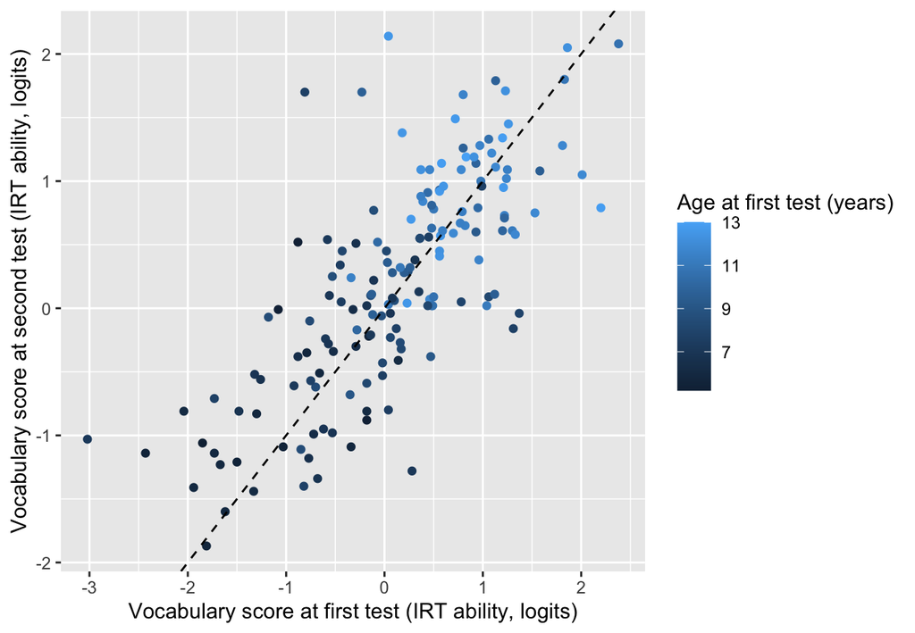

```r
# first vs second score for each retested child; dashed line = identical scores
ggplot(pairs, aes(t1, t2, colour = age_t1)) +
  geom_point() +
  geom_abline(linetype = "dashed") +
  labs(x = "Vocabulary score at first test (IRT ability, logits)",
       y = "Vocabulary score at second test (IRT ability, logits)",
       colour = "Age at first test (years)")
```

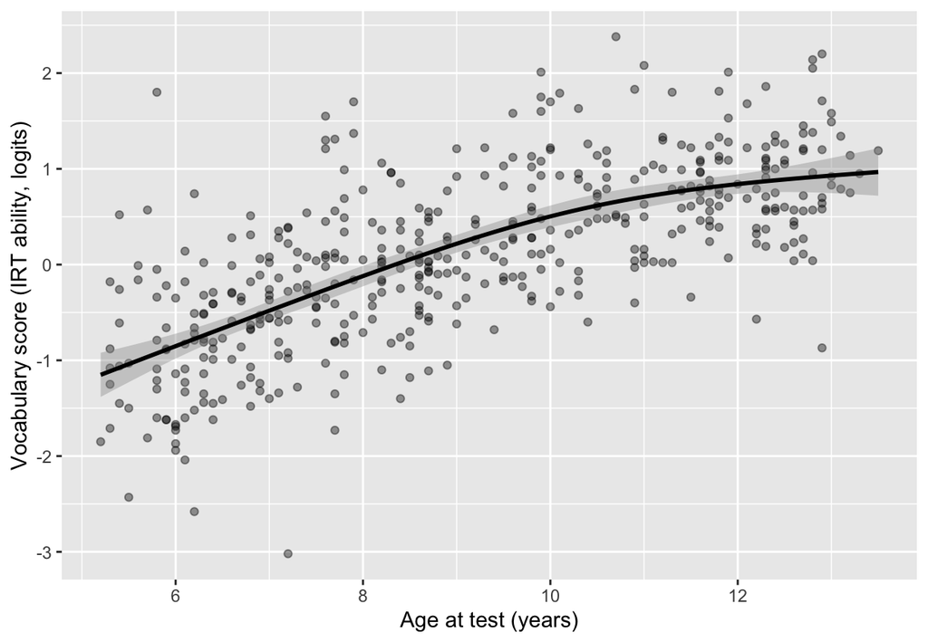

```r
# every Leipzig score against age, with the smooth age curve used in the ICC model
ggplot(leipzig, aes(age, score)) +
  geom_point(alpha = 0.4) +
  geom_smooth(method = "lm", formula = y ~ splines::ns(x, df = 3), colour = "black") +
  labs(x = "Age at test (years)",
       y = "Vocabulary score (IRT ability, logits)")
```

# ICC at a fixed age

## Model

$$\text{score}_{ij} = f(\text{age}_{ij}) + \gamma\,\text{adaptive}_{ij} +
u_i + e_{ij},
\qquad u_i \sim N(0, \tau^2), \quad e_{ij} \sim N(0, \sigma^2)$$

for child *i* at test *j*. $f$ is a natural spline in age with 3 degrees of freedom, which removes the average age trend. `adaptive` shifts scores from the adaptive version of the task. $u_i$ is each child’s stable deviation from same-age peers; $e_{ij}$ is everything that differs from test to test (measurement error plus real fluctuation). The ICC is

$$\text{ICC} = \frac{\tau^2}{\tau^2 + \sigma^2}.$$

Children with one score contribute to the age curve and to the total variance; children with two scores separate $\tau^2$ from $\sigma^2$.

```r
# fit the model by REML
icc_model <- lmer(score ~ splines::ns(age, df = 3) + adaptive + (1 | user_id),
                  data = leipzig, REML = TRUE)
summary(icc_model)
```

```
## Linear mixed model fit by REML ['lmerMod']
## Formula: score ~ splines::ns(age, df = 3) + adaptive + (1 | user_id)
##    Data: leipzig
##
## REML criterion at convergence: 871.1
##
## Scaled residuals:
##     Min      1Q  Median      3Q     Max
## -3.2355 -0.5273 -0.0206  0.4584  3.0592
##
## Random effects:
##  Groups   Name        Variance Std.Dev.
##  user_id  (Intercept) 0.1967   0.4435
##  Residual             0.2279   0.4774
## Number of obs: 455, groups:  user_id, 293
##
## Fixed effects:
##                            Estimate Std. Error t value
## (Intercept)               -1.161863   0.132783  -8.750
## splines::ns(age, df = 3)1  1.578597   0.153387  10.292
## splines::ns(age, df = 3)2  2.860297   0.327132   8.744
## splines::ns(age, df = 3)3  1.560351   0.142232  10.970
## adaptiveTRUE               0.006746   0.048673   0.139
##
## Correlation of Fixed Effects:
##             (Intr) s::(,d=3)1 s::(,d=3)2 s::(,d=3)3
## sp::(,d=3)1 -0.162
## sp::(,d=3)2 -0.913 -0.052
## sp::(,d=3)3 -0.303 -0.262      0.466
## adaptivTRUE -0.133  0.014     -0.093     -0.063
```

```r
# pull the two variance components out of the fitted model
variance_components <- as.data.frame(VarCorr(icc_model))
child_var    <- variance_components$vcov[variance_components$grp == "user_id"]
residual_var <- variance_components$vcov[variance_components$grp == "Residual"]

# ICC and the SD of scores among children of the same age
icc_estimate  <- child_var / (child_var + residual_var)
within_age_sd <- sqrt(child_var + residual_var)

tibble(child_variance = child_var,
       residual_variance = residual_var,
       icc = icc_estimate,
       within_age_sd_logits = within_age_sd)
```

```
## # A tibble: 1 × 4
##   child_variance residual_variance   icc within_age_sd_logits
##            <dbl>             <dbl> <dbl>                <dbl>
## 1          0.197             0.228 0.463                0.652
```

## How much of the residual is measurement error?

Each score has a standard error from the IRT model. Its square is the measurement error variance of that score.

```r
# average squared standard error within each child, then across children
error_var <- leipzig |>
  group_by(user_id) |>
  summarise(child_mean_se2 = mean(score_se^2), .groups = "drop") |>
  summarise(mean_se2 = mean(child_mean_se2)) |>
  pull(mean_se2)

tibble(residual_variance = residual_var,
       measurement_error_variance = error_var,
       share_of_residual = error_var / residual_var)
```

```
## # A tibble: 1 × 3
##   residual_variance measurement_error_variance share_of_residual
##               <dbl>                      <dbl>             <dbl>
## 1             0.228                      0.247              1.08
```

What this means, in plain terms. Each Vocabulary score comes with a standard error from the IRT model: how precisely that one test pins down the child’s ability. Squared and averaged, it says how much scores would bounce around from test to test from imprecision alone (0.247). That is about the same size as the test-to-test variance in the ICC model (0.228).

So when a child’s score changes between two tests a few months apart, the change is about what imprecision alone would produce. There is no sign that children’s vocabulary, relative to same-age peers, actually shifts over those months. The two numbers come from different calculations and are both approximate, so their ratio being a little above 1 means “about equal”, nothing more.

The practical consequence: children’s relative vocabulary level is stable, but one score measures it imprecisely. Among children of the same age, a single score’s reliability is roughly the ICC (0.46). This imprecision is already built into the ICC, and so into the power calculations below. It also means an observed association with the environmental index will be weaker than the true one, which is a reason to consider averaging several language tasks into one outcome.

## Bootstrap confidence intervals

Parametric bootstrap: simulate 500 new datasets from the fitted model, refit each, recompute the ICC, and take the 2.5th and 97.5th percentiles. This is done for all ages and for children aged 9 and under at the time of testing.

```r
# fit the ICC model to any subset of the data
fit_icc <- function(d) {
  lmer(score ~ splines::ns(age, df = 3) + adaptive + (1 | user_id), data = d, REML = TRUE)
}

# ICC from a fitted model: child variance / (child variance + residual variance)
icc_from_model <- function(m) {
  v <- as.data.frame(VarCorr(m))
  v$vcov[v$grp == "user_id"] / sum(v$vcov)
}

# point estimate plus a parametric bootstrap interval; the seed is reset so each call is reproducible
icc_with_ci <- function(d, label, n_boot = 500) {
  m <- fit_icc(d)
  set.seed(seed)
  boot <- bootMer(m, icc_from_model, nsim = n_boot, type = "parametric")
  tibble(ages = label,
         children = n_distinct(d$user_id),
         retested = sum(table(d$user_id) >= 2),
         icc = icc_from_model(m),
         ci_low = unname(quantile(boot$t, 0.025)),
         ci_high = unname(quantile(boot$t, 0.975)))
}
```

```r
# ICC with intervals, all ages and ages 9 and under
icc_results <- bind_rows(
  icc_with_ci(leipzig, "all ages"),
  icc_with_ci(filter(leipzig, age <= 9), "ages 9 and under")
)
icc_results
```

```
## # A tibble: 2 × 6
##   ages             children retested   icc ci_low ci_high
##   <chr>               <int>    <int> <dbl>  <dbl>   <dbl>
## 1 all ages              293      162 0.463  0.343   0.572
## 2 ages 9 and under      159       82 0.451  0.253   0.599
```

## Does the age range change the ICC?

Without age in the model, older children outscore younger ones at every test, so age differences look like stable child differences and inflate the ICC. With age in the model, the ICC should not depend on the age range.

```r
# ICC from a model with a given formula, fitted to a given subset
simple_icc <- function(d, formula) icc_from_model(lmer(formula, data = d, REML = TRUE))

no_age_formula     <- score ~ adaptive + (1 | user_id)
spline_age_formula <- score ~ splines::ns(age, df = 3) + adaptive + (1 | user_id)

# attach each child's age at first test, used to form age bands
leipzig_banded <- left_join(leipzig, select(leipzig_kids, user_id, first_age), by = "user_id")
under_9 <- filter(leipzig, age <= 9)

tibble(
  sample = c("all ages", "all ages", "ages 9 and under", "ages 9 and under"),
  age_in_model = c("no", "yes", "no", "yes"),
  age_sd_years = c(sd(leipzig$age), sd(leipzig$age), sd(under_9$age), sd(under_9$age)),
  icc = c(simple_icc(leipzig, no_age_formula), simple_icc(leipzig, spline_age_formula),
          simple_icc(under_9, no_age_formula), simple_icc(under_9, spline_age_formula))
)
```

```
## # A tibble: 4 × 4
##   sample           age_in_model age_sd_years   icc
##   <chr>            <chr>               <dbl> <dbl>
## 1 all ages         no                   2.29 0.741
## 2 all ages         yes                  2.29 0.463
## 3 ages 9 and under no                   1.06 0.582
## 4 ages 9 and under yes                  1.06 0.451
```

```r
# within two-year bands of age at first test, with a linear age term
band_formula <- score ~ age + adaptive + (1 | user_id)
bands <- list("5 to 7" = c(0, 7), "7 to 9" = c(7, 9), "9 to 11" = c(9, 11), "11 and over" = c(11, Inf))

# for each band: keep children whose first test falls in it, then fit the model
bind_rows(lapply(names(bands), function(b) {
  d <- filter(leipzig_banded, first_age >= bands[[b]][1], first_age < bands[[b]][2])
  tibble(band = b,
         children = n_distinct(d$user_id),
         retested = sum(table(d$user_id) >= 2),
         icc = simple_icc(d, band_formula))
}))
```

```
## # A tibble: 4 × 4
##   band        children retested   icc
##   <chr>          <int>    <int> <dbl>
## 1 5 to 7            72       39 0.666
## 2 7 to 9            84       44 0.302
## 3 9 to 11           68       31 0.652
## 4 11 and over       69       48 0.269
```

The bands have only 30–50 retested children each, so their ICCs are noisy.

# Does the retest gap matter?

The Leipzig children were retested a median of 3.6 months apart, but the border study would test children a year apart. If children’s standing drifts over a year in ways a straight growth line does not capture, that drift counts as test-to-test noise in an annual study, and the ICC estimated from short gaps would be too high.

Two pilot sites differ in their retest gaps: Leipzig at 3.6 months and Bogotá at 15.6 months. Comparing them across all tasks with enough retested children gives a rough sense of how much the gap matters. The comparison is imperfect: site, language, sample and testing conditions differ alongside the gap.

```r
# all tasks at all sites, keeping runs that were scored and have an age
all_tasks <- read_csv("data/scores.csv", show_col_types = FALSE) |>
  filter(is.na(exclusion), !is.na(score), !is.na(age), abs(score) < 8)

# site and task combinations with at least 30 retested children
cells <- all_tasks |>
  group_by(dataset, task_id) |>
  summarise(children = n_distinct(user_id), retested = sum(table(user_id) >= 2), .groups = "drop") |>
  filter(retested >= 30)

# fit the same kind of ICC model in each cell and record the median retest gap:
# lapply walks through the cells, fits the model, and returns one row per cell;
# bind_rows stacks those rows into a table
gap_table <- bind_rows(lapply(seq_len(nrow(cells)), function(i) {

  d <- filter(all_tasks, dataset == cells$dataset[i], task_id == cells$task_id[i])

  # the gap between the first two tests for each retested child
  gaps <- d |>
    group_by(user_id) |>
    filter(n() >= 2) |>
    arrange(age, .by_group = TRUE) |>
    summarise(gap = 12 * (age[2] - age[1]), .groups = "drop")

  # include the version term only where both versions appear in the cell
  f <- if (n_distinct(d$adaptive) > 1) {
    score ~ splines::ns(age, df = 3) + adaptive + (1 | user_id)
  } else {
    score ~ splines::ns(age, df = 3) + (1 | user_id)
  }

  model <- lmer(f, data = d)

  tibble(site = gsub("^pilot_|_main$", "", cells$dataset[i]),
         task = cells$task_id[i],
         retested = cells$retested[i],
         gap_months = round(median(gaps$gap), 1),
         icc = round(icc_from_model(model), 3))
}))
```

```
## boundary (singular) fit: see help('isSingular')
```

```r
# show the cells, shortest gaps first
gap_table |> arrange(gap_months, site, task) |> print(n = Inf)
```

```
## # A tibble: 16 × 5
##    site               task                     retested gap_months   icc
##    <chr>              <chr>                       <int>      <dbl> <dbl>
##  1 mpieva_de          egma-math                     164        3.6 0.658
##  2 mpieva_de          hearts-and-flowers            170        3.6 0.368
##  3 mpieva_de          matrix-reasoning              149        3.6 0.483
##  4 mpieva_de          mental-rotation               128        3.6 0.553
##  5 mpieva_de          same-different-selection      153        3.6 0.464
##  6 mpieva_de          theory-of-mind                145        3.6 0.369
##  7 mpieva_de          trog                          100        3.6 0.373
##  8 mpieva_de          vocab                         162        3.6 0.463
##  9 mpieva_de          memory-game                   156        4.8 0.312
## 10 uniandes_co_bogota egma-math                     234       15.6 0.577
## 11 uniandes_co_bogota hearts-and-flowers             52       15.6 0.156
## 12 uniandes_co_bogota memory-game                    31       15.6 0
## 13 uniandes_co_bogota mental-rotation                49       15.6 0.548
## 14 uniandes_co_bogota sre                           164       15.6 0.575
## 15 uniandes_co_bogota swr                           167       15.6 0.337
## 16 uniandes_co_bogota trog                           75       15.6 0.353
```

```r
# the typical ICC at each gap length
gap_table |>
  mutate(gap_group = ifelse(gap_months < 9, "short gaps (3-5 months)", "annual gaps (15-17 months)")) |>
  group_by(gap_group) |>
  summarise(cells = n(), median_icc = round(median(icc), 3))
```

```
## # A tibble: 2 × 3
##   gap_group                  cells median_icc
##   <chr>                      <int>      <dbl>
## 1 annual gaps (15-17 months)     7      0.353
## 2 short gaps (3-5 months)        9      0.463
```

```r
# compare the same task across the two sites, in steps:
# select keeps the three columns needed; pivot_wider puts each site in its own column;
# filter keeps tasks measured at both sites; mutate computes the ratio of the two ICCs
gap_table |>
  select(site, task, icc) |>
  tidyr::pivot_wider(names_from = site, values_from = icc) |>
  filter(!is.na(mpieva_de), !is.na(uniandes_co_bogota)) |>
  mutate(ratio = round(uniandes_co_bogota / mpieva_de, 2)) |>
  rename(leipzig_3.6_months = mpieva_de, bogota_15.6_months = uniandes_co_bogota)
```

```
## # A tibble: 5 × 4
##   task               leipzig_3.6_months bogota_15.6_months ratio
##   <chr>                           <dbl>              <dbl> <dbl>
## 1 egma-math                       0.658              0.577  0.88
## 2 hearts-and-flowers              0.368              0.156  0.42
## 3 memory-game                     0.312              0      0
## 4 mental-rotation                 0.553              0.548  0.99
## 5 trog                            0.373              0.353  0.95
```

Bogotá’s Vocabulary cell is too thin to include here (29 retested children). Its ICC comes out at .12, but that rests on a handful of children whose scores moved 2 to 3 logits, and the retest correlation rises to .55 if the three largest movers are dropped. Bogotá’s wave-1 Vocabulary runs also attempted far fewer items than Leipzig’s (a median of 49 against 115), so those scores are less precise. It sits well below Bogotá’s own better-measured tasks (math .58, mental rotation .55).

What this suggests: stability at annual gaps is somewhat lower than at three months, with the typical ICC falling from about .46 to about .35 across tasks, rather than collapsing. The ICC used above (0.46) is therefore probably a little optimistic for an annual design, and the lower end of its confidence interval (0.34) is a reasonable stand-in for the annual case. Because site and gap are confounded here, this bounds the problem rather than settling it.

# Average growth in Vocabulary scores

Used only to put the effect size in context. Two estimates:

- **Within children**: each retested child’s change divided by the time between tests, averaged across children. Every retested Leipzig child took the non-adaptive version first and the adaptive version second, so this change also contains any difference between versions, and short gaps make each child’s yearly rate noisy.
- **Across ages**: the slope of score on age, using each child’s first score. This is not affected by the version switch, and it is the estimate used below.

```r
# within children: change per year for each retested child, then summarised across children
within_child_growth <- pairs |>
  mutate(change_per_year = (t2 - t1) / (gap_months / 12)) |>
  summarise(children = n(),
            mean_logits_per_year = mean(change_per_year),
            median_logits_per_year = median(change_per_year))
within_child_growth
```

```
## # A tibble: 1 × 3
##   children mean_logits_per_year median_logits_per_year
##      <int>                <dbl>                  <dbl>
## 1      162                0.512                  0.283
```

```r
# across ages: keep each child's earliest score, then regress score on age
first_scores <- leipzig |>
  group_by(user_id) |>
  slice_min(age, n = 1, with_ties = FALSE) |>
  ungroup()

age_slope_model <- lm(score ~ age + adaptive, data = first_scores)
average_growth_logits <- coef(age_slope_model)[["age"]]
age_slope_ci <- confint(age_slope_model, "age")

tibble(children = nrow(first_scores),
       age_slope_logits_per_year = average_growth_logits,
       ci_low = age_slope_ci[1],
       ci_high = age_slope_ci[2],
       age_slope_sd_per_year = average_growth_logits / within_age_sd)
```

```
## # A tibble: 1 × 5
##   children age_slope_logits_per_year ci_low ci_high age_slope_sd_per_year
##      <int>                     <dbl>  <dbl>   <dbl>                 <dbl>
## 1      293                     0.269  0.233   0.306                 0.413
```

# Power for the border cohort

## Approach

Power is estimated by simulation with the **simr** package (Green & MacLeod, 2016, *Methods in Ecology and Evolution*). The steps:

- Build an artificial version of the study: the children, the waves at which each child is tested, who drops out, and each child’s environmental index score.
- Write down the analysis model and fill in its values: the ICC estimated above, the assumed spread of growth rates, and the growth effect to detect.
- simr generates Vocabulary scores for that study from the model, fits the model to them with `lmer`, and tests the index × time effect. It does this many times.
- Power is the share of simulated studies in which the index × time effect is significant at α = .05.

## The model

For child *i* at wave *j* (time $t_{ij}$ = 0, 1 or 2 years after the first test):

$$y_{ij} = b_0 + u_{0i} + (b_1 + u_{1i})\,t_{ij} + \beta_{\text{level}}
X_i + \beta_{\text{growth}} X_i t_{ij} + e_{ij}$$

- $y_{ij}$ is the child’s Vocabulary score at that wave, in units of the within-age SD estimated above (logits divided by that SD, not re-standardized at each wave, so growth is kept).
- $b_0$ is the average starting score (set to 0; it does not affect power) and $b_1$ is the average yearly growth (the age slope estimated above, in SD per year).
- $u_{0i}$ is how far child *i* starts above or below average; its variance is the ICC.
- $u_{1i}$ is how much faster or slower than average child *i* grows; its SD is the assumed growth SD. Starting level and growth rate are assumed uncorrelated.
- $e_{ij}$ is test-to-test noise, with variance 1 − ICC, so a single first-wave score has total variance 1.
- $X_i$ is the child’s environmental index, standardized (mean 0, SD 1).
- $\beta_{\text{level}}$ is set to 0: it is not the effect being tested, and it does not change power for the growth effect.
- $\beta_{\text{growth}}$ is the tested effect: extra growth per year, in SD, for each SD of the index.

In `lmer` notation this is `y ~ time * index + (1 + time | child)`.

## Settings

```r
# the three enrolment sizes being compared; the L stores them as whole numbers (integers),
# so they can be matched exactly later without comparing decimal numbers
n_enrolled <- c(300L, 320L, 360L)

# the share of enrolled children still being tested at wave 1, wave 2 and wave 3:
# everyone at wave 1, 90% at wave 2 (10% lost), 80% at wave 3 (20% lost in total)
retention <- c(1.00, 0.90, 0.80)

# how much children differ in their yearly growth rate, as an SD in within-age SD units per year;
# this is an assumption, not estimated from the pilot data
growth_sd <- 0.15

# average yearly growth in within-age SD units: the age slope in logits divided by the within-age SD;
# it sets b1 in the model, which makes the simulated scores realistic but does not change power
average_growth_sd <- average_growth_logits / within_age_sd

# the significance threshold for a two-sided test
alpha <- 0.05

# the power we want the study to have (an 80% chance of detecting a true effect)
target_power <- 0.80

# the growth effect whose power we estimate: 0.08 SD of extra Vocabulary growth per year
# for each 1 SD higher on the environmental index
target_effect <- 0.08

# the number of simulated studies for each setting in the main table; with 1000 simulations
# a power near .75 is estimated to within about ±0.03 (95% interval)
n_sims <- 1000

# fewer simulations for the sensitivity table, which is only there to show the direction of change
n_sims_sensitivity <- 500

# the ICC estimate and its 95% interval from the bootstrap above, stored with names so each can be looked up
icc_all <- filter(icc_results, ages == "all ages")
icc_values <- c(estimate = icc_all$icc, ci_low = icc_all$ci_low, ci_high = icc_all$ci_high)
icc_values
```

```
##  estimate    ci_low   ci_high
## 0.4633359 0.3426775 0.5720609
```

## Building the simulated study

```r
# make_design() builds the explanatory data for one study with n enrolled children:
# one row per test actually taken, with the child's id, the time of the test in years,
# and the child's environmental index score (no Vocabulary scores yet; simr adds those)
make_design <- function(n) {

  # reset the random seed so the same index scores and dropout pattern are produced every time
  set.seed(seed)

  # how many children are last tested at wave 1, wave 2 and wave 3:
  # -diff(retention) is c(0.10, 0.10), the shares lost after waves 1 and 2, and retention[3] is the
  # 0.80 who complete all three; multiplying by n and rounding turns shares into counts
  n_last_wave <- round(n * c(-diff(retention), retention[3]))

  # stop with an error if rounding made the counts add up to something other than n
  stopifnot(sum(n_last_wave) == n)

  # one row per child:
  # child is an id stored as a factor, because lmer groups rows by it;
  # index is drawn from a normal distribution, then scale() makes its mean exactly 0 and SD exactly 1;
  # last_wave repeats 1, 2 and 3 as many times as the counts above, then sample() shuffles them across children
  children <- tibble(
    child = factor(seq_len(n)),
    index = as.numeric(scale(rnorm(n))),
    last_wave = sample(rep(1:3, times = n_last_wave))
  )

  # expand to one row per test in steps:
  # crossing gives every child a row for each time 0, 1 and 2;
  # filter then drops the waves after each child's last test (time 0 is wave 1, so a child whose
  # last wave is 2 keeps times 0 and 1)
  children |>
    tidyr::crossing(time = 0:2) |>
    filter(time < last_wave)
}

# look at the design for N = 360: how many children are tested at each time point
# (count() tallies the rows at each value of time)
make_design(360L) |>
  count(time, name = "children_tested")
```

```
## # A tibble: 3 × 2
##    time children_tested
##   <int>           <int>
## 1     0             360
## 2     1             324
## 3     2             288
```

```r
# make_model() builds an artificial lmer model with the effects and variances filled in,
# for a given design, ICC, growth effect and growth SD
make_model <- function(design, icc, effect = target_effect, slope_sd = growth_sd) {

  # makeLmer() from simr creates a model object without any real Vocabulary data:
  # formula is the analysis model;
  # fixef gives the fixed effects in the order lmer lists them for this formula:
  #   intercept (b0 = 0), time (b1 = average growth), index (beta level = 0), time:index (beta growth);
  # VarCorr is the 2 x 2 covariance matrix of each child's own level and growth:
  #   diagonal entries are the ICC and the growth SD squared, off-diagonal entries 0 (uncorrelated);
  # sigma is the SD of test-to-test noise, the square root of 1 - ICC;
  # data is the design built by make_design()
  makeLmer(y ~ time * index + (1 + time | child),
           fixef = c(0, average_growth_sd, 0, effect),
           VarCorr = diag(c(icc, slope_sd^2)),
           sigma = sqrt(1 - icc),
           data = design)
}

# build the model for N = 360 at the ICC estimate and print what was filled in, to check it
example_model <- make_model(make_design(360L), icc_values[["estimate"]])
fixef(example_model)
```

```
## (Intercept)        time       index  time:index
##   0.0000000   0.4133103   0.0000000   0.0800000
```

```r
VarCorr(example_model)
```

```
##  Groups   Name        Std.Dev. Corr
##  child    (Intercept) 0.68069
##           time        0.15000  0.000
##  Residual             0.73257
```

```r
sigma(example_model)
```

```
## [1] 0.7325736
```

```r
# run_power() simulates many studies for one setting and returns the estimated power
run_power <- function(n, icc, slope_sd = growth_sd, nsim = n_sims) {

  # build the study design and the model for this setting
  model <- make_model(make_design(n), icc, slope_sd = slope_sd)

  # powerSim() repeats nsim times: simulate Vocabulary scores from the model, refit
  # y ~ time * index + (1 + time | child) with lmer, and test the time:index effect;
  # fixed("time:index", "sa") picks that effect and the Satterthwaite t-test (from lmerTest);
  # alpha is the significance threshold; seed makes the simulations reproducible;
  # progress = FALSE hides the progress bar
  sims <- powerSim(model,
                   test = fixed("time:index", "sa"),
                   nsim = nsim,
                   alpha = alpha,
                   seed = seed,
                   progress = FALSE)

  # summary() gives the number of significant results, the number of simulations,
  # the power (their ratio), and a 95% interval for the power
  result <- summary(sims)

  # return one row: the setting, the power with its interval, and how many simulated fits
  # produced a warning (usually a singular fit, when the growth-rate variance is estimated at 0)
  # or an error
  tibble(n = n,
         icc = icc,
         growth_sd = slope_sd,
         simulations = nsim,
         power = result$mean,
         power_ci_low = result$lower,
         power_ci_high = result$upper,
         fits_with_warnings = length(unique(sims$warnings$index)),
         fits_with_errors = length(unique(sims$errors$index)))
}
```

## Power at each sample size

This chunk runs 9 settings × 1000 simulations and takes several minutes. It is cached, so it only reruns when its code or inputs change.

```r
# every combination of sample size and ICC value (3 x 3 = 9 settings), in steps:
# expand.grid makes the combinations; mutate looks up the numeric ICC for each name
settings <- expand.grid(n = n_enrolled, icc_used = names(icc_values), stringsAsFactors = FALSE) |>
  mutate(icc = icc_values[icc_used])

# run the simulations for each setting in turn:
# lapply goes through the row numbers of settings, runs run_power() for that row,
# and adds a column saying which ICC value was used; bind_rows stacks the nine results into one table
power_table <- bind_rows(lapply(seq_len(nrow(settings)), function(i) {
  run_power(settings$n[i], settings$icc[i]) |>
    mutate(icc_used = settings$icc_used[i], .before = icc)
}))
```

The smallest effect detectable with 80% power is worked out from the simulated power. For a test like this, power ≈ Φ(β / SE − 1.96), where Φ is the normal cumulative distribution. Solving for the standard error gives SE = β / (Φ⁻¹(power) + 1.96), and the effect needed for 80% power is SE × (1.96 + 0.84).

```r
# add the smallest detectable effect to the table in steps:
# implied_se is the standard error implied by the simulated power at the target effect;
# smallest_effect_sd_per_year is that standard error times 1.96 + 0.84 (the z values for a two-sided
# .05 test and for 80% power)
power_table <- power_table |>
  mutate(implied_se = target_effect / (qnorm(power) + qnorm(1 - alpha / 2)),
         smallest_effect_sd_per_year = implied_se * (qnorm(1 - alpha / 2) + qnorm(target_power)))

# show every column
print(power_table, width = Inf)
```

```
## # A tibble: 9 × 12
##       n icc_used   icc growth_sd simulations power power_ci_low power_ci_high
##   <int> <chr>    <dbl>     <dbl>       <dbl> <dbl>        <dbl>         <dbl>
## 1   300 estimate 0.463      0.15        1000 0.63         0.599         0.660
## 2   320 estimate 0.463      0.15        1000 0.705        0.676         0.733
## 3   360 estimate 0.463      0.15        1000 0.738        0.710         0.765
## 4   300 ci_low   0.343      0.15        1000 0.562        0.531         0.593
## 5   320 ci_low   0.343      0.15        1000 0.635        0.604         0.665
## 6   360 ci_low   0.343      0.15        1000 0.677        0.647         0.706
## 7   300 ci_high  0.572      0.15        1000 0.723        0.694         0.751
## 8   320 ci_high  0.572      0.15        1000 0.787        0.760         0.812
## 9   360 ci_high  0.572      0.15        1000 0.828        0.803         0.851
##   fits_with_warnings fits_with_errors implied_se smallest_effect_sd_per_year
##                <int>            <int>      <dbl>                       <dbl>
## 1                 29                0     0.0349                      0.0978
## 2                 38                0     0.0320                      0.0897
## 3                 37                0     0.0308                      0.0863
## 4                 44                0     0.0378                      0.106
## 5                 34                0     0.0347                      0.0972
## 6                 43                0     0.0331                      0.0926
## 7                 33                0     0.0314                      0.0878
## 8                 31                0     0.0290                      0.0813
## 9                 36                0     0.0275                      0.0771
```

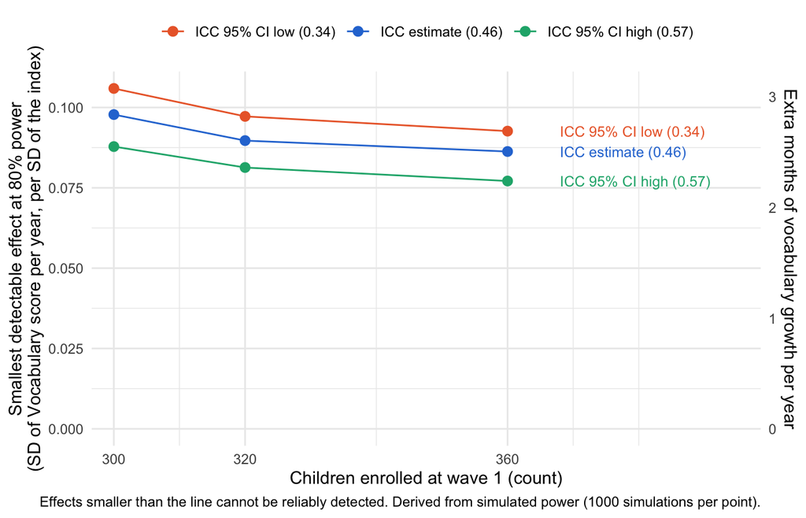

```r
# readable names for the three ICC values, used in the legend and the labels
icc_labels <- c(estimate = sprintf("ICC estimate (%.2f)", icc_values[["estimate"]]),
                ci_low   = sprintf("ICC 95%% CI low (%.2f)", icc_values[["ci_low"]]),
                ci_high  = sprintf("ICC 95%% CI high (%.2f)", icc_values[["ci_high"]]))

# prepare the plot data: add the readable ICC name, ordered high, estimate, low
# (a higher ICC gives a smaller detectable effect, so this orders the lines top to bottom)
plot_data <- power_table |>
  mutate(icc_label = factor(icc_labels[icc_used],
                            levels = icc_labels[c("ci_low", "estimate", "ci_high")]))

# how many months of vocabulary growth one unit on the y axis is worth, used for the second axis:
# an effect of 1 SD per year equals this many months of ordinary growth per year
months_per_sd_year <- 12 * within_age_sd / average_growth_logits

# draw the plot layer by layer:
# a line and points for each ICC value;
# a label at the right-hand end of each line naming the ICC value;
# fixed colours, breaks at the sample sizes compared, room on the right for the labels;
# the left axis in SD per year and the right axis the same numbers as months of growth per year
ggplot(plot_data, aes(n, smallest_effect_sd_per_year, colour = icc_label, group = icc_label)) +
  geom_line() +
  geom_point(size = 2.5) +
  geom_text(data = filter(plot_data, n == max(n_enrolled)),
            aes(label = icc_label), hjust = 0, nudge_x = 8, size = 3.2, show.legend = FALSE) +
  scale_colour_manual(values = c("#eb6834", "#2a78d6", "#1baf7a")) +
  scale_x_continuous(breaks = n_enrolled, expand = expansion(mult = c(0.05, 0.45))) +
  scale_y_continuous(
    limits = c(0, NA),
    sec.axis = sec_axis(~ . * months_per_sd_year,
                        name = "Extra months of vocabulary growth per year")) +
  labs(x = "Children enrolled at wave 1 (count)",
       y = "Smallest detectable effect at 80% power\n(SD of Vocabulary score per year, per SD of the index)",
       colour = NULL,
       caption = "Effects smaller than the line cannot be reliably detected. Derived from simulated power (1000 simulations per point).") +
  theme_minimal() +
  theme(legend.position = "top")
```

## Sensitivity to the assumed growth SD

The between-child SD of growth rates cannot be estimated from these data: no child has more than two scores, and those are a few months apart. This table shows how much the answer depends on that assumption, at N = 360 and the ICC estimate, with 500 simulations each.

```r
# run the simulations once for each growth SD to try, then stack the results into one table:
# lapply goes through the growth SDs and calls run_power() at N = 360 and the ICC estimate
growth_sd_table <- bind_rows(lapply(c(0.05, 0.10, 0.15, 0.25), function(sd_value) {
  run_power(360L, icc_values[["estimate"]], slope_sd = sd_value, nsim = n_sims_sensitivity)
}))

# show every column
print(growth_sd_table, width = Inf)
```

```
## # A tibble: 4 × 9
##       n   icc growth_sd simulations power power_ci_low power_ci_high
##   <int> <dbl>     <dbl>       <dbl> <dbl>        <dbl>         <dbl>
## 1   360 0.463      0.05         500 0.764        0.724         0.801
## 2   360 0.463      0.1          500 0.75         0.710         0.787
## 3   360 0.463      0.15         500 0.734        0.693         0.772
## 4   360 0.463      0.25         500 0.686        0.643         0.726
##   fits_with_warnings fits_with_errors
##                <int>            <int>
## 1                 27                0
## 2                 27                0
## 3                 19                0
## 4                  8                0
```

More spread in growth rates makes the average growth rate harder to pin down, so power falls, but only modestly across this range.

# What the effect sizes mean

Effects here are in SD of Vocabulary score per year, for each SD of the environmental index. That is a difference in growth *rates*, so it accumulates: the gap between two children keeps widening as long as the study runs. The function below restates any such effect in easier terms.

```r
# describe_effect() restates a growth effect (in SD per year, per SD of the index) in other units
describe_effect <- function(beta) {

  # the same effect in logits per year: SD units times the within-age SD of Vocabulary scores
  logits_per_year <- beta * within_age_sd

  # how many months of ordinary vocabulary development that equals: the effect divided by
  # how much scores rise with one year of age, times 12 months
  months_per_year <- 12 * logits_per_year / average_growth_logits

  # the gap between two children 1 SD apart on the index after two years (wave 1 to wave 3)
  gap_by_wave_3 <- 2 * beta

  # the SD of scores at wave 3: baseline variance 1, plus the spread added by two years of
  # differing growth rates, plus the spread added by the index effect itself
  wave_3_sd <- sqrt(1 + 4 * growth_sd^2 + 4 * beta^2)

  tibble(
    # the effect as given
    effect_sd_per_year = beta,
    # extra months of vocabulary growth per year, for a child 1 SD higher on the index
    extra_months_per_year = months_per_year,
    # the same, accumulated over the two years from wave 1 to wave 3
    extra_months_by_wave_3 = 2 * months_per_year,
    # Cohen's d at wave 3 for two children 1 SD apart on the index
    cohens_d_1_sd_apart = gap_by_wave_3 / wave_3_sd,
    # Cohen's d at wave 3 for the top half vs the bottom half of the index: the average index values
    # of the two halves differ by 2 * sqrt(2 / pi), about 1.6 SD
    cohens_d_median_split = 2 * sqrt(2 / pi) * gap_by_wave_3 / wave_3_sd,
    # the correlation between the index and children's true growth rates
    r_with_true_growth = beta / sqrt(beta^2 + growth_sd^2)
  )
}
```

## The effect we power for

```r
# restate the target effect of .08 SD/year in the other units
describe_effect(target_effect) |> print(width = Inf)
```

```
## # A tibble: 1 × 6
##   effect_sd_per_year extra_months_per_year extra_months_by_wave_3
##                <dbl>                 <dbl>                  <dbl>
## 1               0.08                  2.32                   4.65
##   cohens_d_1_sd_apart cohens_d_median_split r_with_true_growth
##                 <dbl>                 <dbl>              <dbl>
## 1               0.151                 0.242              0.471
```

Read the row like this: a child 1 SD higher on the environmental index gains about that many extra months of vocabulary development per year, and roughly twice that by the third wave. The Cohen’s d columns compare children’s scores at wave 3: first for two children 1 SD apart on the index, then for the top half against the bottom half of the index. By Cohen’s rule of thumb, 0.2 is small.

## The smallest effects each sample size can detect

```r
# restate each sample size's smallest detectable effect in the same units, in steps:
# filter keeps the rows simulated at the ICC estimate (one per sample size);
# lapply runs describe_effect() on each of those effects and bind_rows stacks the results;
# the sample sizes are added back as the first column
smallest_effects <- power_table |>
  filter(icc_used == "estimate")

bind_rows(lapply(smallest_effects$smallest_effect_sd_per_year, describe_effect)) |>
  mutate(n = smallest_effects$n, .before = everything()) |>
  print(width = Inf)
```

```
## # A tibble: 3 × 7
##       n effect_sd_per_year extra_months_per_year extra_months_by_wave_3
##   <int>              <dbl>                 <dbl>                  <dbl>
## 1   300             0.0978                  2.84                   5.68
## 2   320             0.0897                  2.60                   5.21
## 3   360             0.0863                  2.51                   5.01
##   cohens_d_1_sd_apart cohens_d_median_split r_with_true_growth
##                 <dbl>                 <dbl>              <dbl>
## 1               0.184                 0.294              0.546
## 2               0.169                 0.270              0.513
## 3               0.163                 0.260              0.499
```

## Why these effects look small in SD but not in correlation

Children’s growth rates do not vary much: the assumed SD is 0.15 SD/year. So an effect of 0.08 SD/year explains a sizeable share of the differences in how fast children learn vocabulary, which is why the correlation with true growth rates is around .5 even though Cohen’s d is small. The d values are small because they compare scores at a single wave, where stable differences between children, which are much larger, dominate.

# Every LEVANTE task at Leipzig

The study will administer the full LEVANTE battery, so the same calculation is worth running for every task with enough retested children. Tasks differ in two ways that matter: how stable children’s scores are (the ICC), and how fast scores grow with age, which sets how big a detectable effect is in everyday terms.

Simulating all of them would take hours, so this section uses the formula for the standard error of the growth effect instead. The check below shows it reproduces the Vocabulary simulations.

```r
# the standard error of the growth effect, worked out from the expected information rather than
# by simulation: G holds the variance of children's starting levels and growth rates,
# last_wave_share splits children by the wave they are last tested at, and each group's
# information is added up before being inverted
growth_se_formula <- function(n, icc, slope_sd = growth_sd, keep = retention) {
  G <- diag(c(icc, slope_sd^2))
  last_wave_share <- c(-diff(keep), keep[3])
  info <- matrix(0, 2, 2)
  for (k in 1:3) {
    A <- cbind(1, 0:(k - 1))
    V <- A %*% G %*% t(A) + diag(1 - icc, k)
    info <- info + n * last_wave_share[k] * t(A) %*% solve(V) %*% A
  }
  sqrt(solve(info)[2, 2])
}

# compare the formula with the Vocabulary simulations already run, setting by setting:
# rowwise runs the calculation one row at a time, and the two columns should agree
# to within simulation error (about plus or minus .03)
power_table |>
  rowwise() |>
  mutate(formula_power = pnorm(target_effect / growth_se_formula(n, icc) - qnorm(1 - alpha / 2))) |>
  ungroup() |>
  transmute(n, icc_used,
            simulated_power = round(power, 3),
            formula_power = round(formula_power, 3),
            difference = round(power - formula_power, 3))
```

```
## # A tibble: 9 × 5
##       n icc_used simulated_power formula_power difference
##   <int> <chr>              <dbl>         <dbl>      <dbl>
## 1   300 estimate           0.63          0.661     -0.031
## 2   320 estimate           0.705         0.689      0.016
## 3   360 estimate           0.738         0.739     -0.001
## 4   300 ci_low             0.562         0.583     -0.021
## 5   320 ci_low             0.635         0.611      0.024
## 6   360 ci_low             0.677         0.662      0.015
## 7   300 ci_high            0.723         0.747     -0.024
## 8   320 ci_high            0.787         0.773      0.014
## 9   360 ci_high            0.828         0.82       0.008
```

```r
# Leipzig scores for every task, from the data already loaded for the gap comparison
leipzig_all <- filter(all_tasks, dataset == "pilot_mpieva_de_main")

# tasks with at least 30 children tested more than once
tasks_with_retests <- leipzig_all |>
  group_by(task_id) |>
  summarise(retested = sum(table(user_id) >= 2), .groups = "drop") |>
  filter(retested >= 30)

# for each task: fit the ICC model, measure how fast scores grow with age, and work out
# the smallest effect the study could detect
task_table <- bind_rows(lapply(tasks_with_retests$task_id, function(this_task) {

  d <- filter(leipzig_all, task_id == this_task)

  # include the version term only where both versions appear for this task
  f <- if (n_distinct(d$adaptive) > 1) {
    score ~ splines::ns(age, df = 3) + adaptive + (1 | user_id)
  } else {
    score ~ splines::ns(age, df = 3) + (1 | user_id)
  }
  model <- lmer(f, data = d)

  # the two variance components, the ICC, and the SD of scores among same-age children
  v <- as.data.frame(VarCorr(model))
  child_var <- v$vcov[v$grp == "user_id"]
  residual_var <- v$vcov[v$grp == "Residual"]
  icc <- child_var / (child_var + residual_var)
  within_sd <- sqrt(child_var + residual_var)

  # how fast scores rise with age: keep each child's first score, then regress on age
  first_scores <- d |>
    group_by(user_id) |>
    slice_min(age, n = 1, with_ties = FALSE) |>
    ungroup()
  growth_per_year <- coef(lm(score ~ age, data = first_scores))[["age"]]

  # the smallest detectable effect at each sample size, and what the N = 300 one is worth
  # in months of ordinary growth accumulated by wave 3
  mde <- function(n) growth_se_formula(n, icc) * (qnorm(1 - alpha / 2) + qnorm(target_power))

  tibble(task = this_task,
         retested = sum(table(d$user_id) >= 2),
         icc = round(icc, 3),
         within_age_sd = round(within_sd, 2),
         growth_per_year = round(growth_per_year, 3),
         error_share_of_residual = round(mean(d$score_se^2, na.rm = TRUE) / residual_var, 2),
         mde_300 = round(mde(300), 3),
         mde_360 = round(mde(360), 3),
         months_by_wave_3_at_300 = round(2 * 12 * mde(300) * within_sd / growth_per_year, 1))
}))

# show the tasks, most sensitive first
task_table |> arrange(mde_300) |> print(n = Inf, width = Inf)
```

```
## # A tibble: 9 × 9
##   task                     retested   icc within_age_sd growth_per_year
##   <chr>                       <int> <dbl>         <dbl>           <dbl>
## 1 egma-math                     164 0.658          1.31           0.678
## 2 mental-rotation               128 0.553          0.88           0.226
## 3 matrix-reasoning              149 0.483          1.48           0.412
## 4 same-different-selection      153 0.464          1.26           0.128
## 5 vocab                         162 0.463          0.65           0.269
## 6 hearts-and-flowers            170 0.368          2.2            0.695
## 7 theory-of-mind                145 0.369          0.7            0.147
## 8 trog                          100 0.373          0.69           0.152
## 9 memory-game                   156 0.312          0.66           0.175
##   error_share_of_residual mde_300 mde_360 months_by_wave_3_at_300
##                     <dbl>   <dbl>   <dbl>                   <dbl>
## 1                    0.53   0.078   0.071                     3.6
## 2                    0.81   0.087   0.08                      8.2
## 3                    0.57   0.093   0.085                     8
## 4                    0.44   0.094   0.086                    22.3
## 5                    1.06   0.094   0.086                     5.5
## 6                    0.19   0.101   0.093                     7.7
## 7                    1.54   0.101   0.093                    11.5
## 8                    1.04   0.101   0.092                    11
## 9                    0.9    0.105   0.096                     9.5
```

How to read this:

- **Math is the most sensitive outcome.** Its ICC of .66 gives the smallest detectable effect, and because math grows quickly, that effect is worth only about three and a half months of development by wave 3.
- **Vocabulary is middling on the ICC but good in everyday terms**, because its growth rate is healthy relative to its spread.
- **Slow-growing tasks are hard to interpret.** Same and Different has an ICC close to Vocabulary’s, but grows so slowly that a detectable effect equals well over a year of development.
- **Executive function tasks are the weakest.** Hearts and Flowers and Memory have the lowest ICCs.
- **The error share says what would help.** Where it is near 1 (Vocabulary, TROG, Theory of Mind), the test-to-test variation is measurement imprecision, so a longer test would raise the ICC. Where it is low (Hearts and Flowers), children genuinely vary from day to day, and more items will not fix that.

The ROAR reading tasks are missing here: Leipzig has too few children retested on them. They appear at Bogotá in the gap comparison above.

These come from retests 3.6 months apart, so the annual-gap discount in the gap section applies to every task.

# Reproducibility check

Re-run the all-ages bootstrap with the same seed and confirm the result matches.

```r
# repeat the bootstrap and compare with the first run, allowing only floating-point tolerance
second_run <- icc_with_ci(leipzig, "all ages")
identical_results <- isTRUE(all.equal(icc_all, second_run, tolerance = 1e-10))
cat("Bootstrap results identical on re-run:", identical_results, "\n")
```

```
## Bootstrap results identical on re-run: TRUE
```

Re-run one simr setting (N = 360 at the ICC estimate) with the same seed and confirm the simulated power matches the table.

```r
# simulate the N = 360, ICC estimate setting again
repeat_run <- run_power(360L, icc_values[["estimate"]])

# the same setting from the power table
first_run <- filter(power_table, n == 360L, icc_used == "estimate")

# compare the two powers, allowing only floating-point tolerance
cat("simr power identical on re-run:",
    isTRUE(all.equal(first_run$power, repeat_run$power, tolerance = 1e-12)), "\n")
```

```
## simr power identical on re-run: TRUE
```

# Methods summary

We estimated the between-child share of variance (ICC) in LEVANTE Vocabulary scores among children of the same age using the public LEVANTE pilot release. Leipzig was the only site with enough children tested twice: 455 scores from 293 children aged 5.2–13.5 years, 162 of whom were retested a median of 3.6 months apart. Scores were IRT ability estimates (Rasch model, logits). We fitted a linear mixed model with a natural spline for age (3 df), a fixed effect of adaptive administration, and a random intercept for child (REML; lme4). The ICC was the child intercept variance divided by the sum of the intercept and residual variances, with a 95% interval from 500 parametric bootstrap refits. The ICC was 0.46 (95% CI 0.34–0.57).

Power was estimated by simulation with simr (Green & MacLeod, 2016). Each simulated study enrolled N children tested at 0, 1 and 2 years, with 10% last tested at wave 1 and a further 10% at wave 2, and a standardized environmental index for each child. Vocabulary scores were generated from a growth model with a random intercept for each child (variance equal to the ICC), a random slope (SD 0.15 SD/year, uncorrelated with the intercept), residual variance 1 − ICC, and an index × time effect of β = 0.08 SD/year. Each simulated dataset was analysed with `lmer(y ~ time * index + (1 + time | child))`, and the index × time effect was tested with a Satterthwaite t-test (α = 0.05), over 1000 simulations per setting. With 360 children enrolled, power was 0.74 (95% CI 0.71–0.77), and the smallest effect detectable with 80% power, derived from the simulated power, was β = 0.086 SD/year (300 children: 0.098).

# Caveats

- One site (Leipzig, German-language scores), ages 5–13. The border cohort is 4–8 and Spanish/English.
- Retests were months apart, not a year, so the ICC reflects short-term stability.
- Some children switched from the non-adaptive to the adaptive version between tests; the model includes a version effect.
- The growth SD (.15 SD/year) and the target effect (.08 SD/year) are assumptions, not estimates.
- Simulated power has its own uncertainty: with 1000 simulations, about ±0.03 (the 95% intervals are shown in the table).

# Proposal text

Pasted from the proposal draft, as written.

> Our primary analyses are longitudinal multilevel growth models relating measures of environmental predictability and heterogeneity to the level and rate of change of LEVANTE measurement scores at baseline and across three annual waves.

> First, we describe the novel composite indexes. We will construct composite indices for heterogeneity and predictability using the caregiver surveys and EMA data from each wave. We will construct a domain-general index as our primary pre-registered comparison, with domain-specific linguistic and social indexes as secondary comparisons. The overall heterogeneity index will incorporate the number and diversity of settings, social partners, and languages a child regularly experiences, including cross-border contexts and language mixing. The predictability index will incorporate data on the places, people, languages, and activities children encounter on a day-to-day timescale. We will confirm that the two indices are only modestly correlated so that their effects can be separated. Each index will be standardized within our sample and entered as a continuous predictor of the level and rate of change of LEVANTE scores. Head-mounted videos will be used to validate these indices against denser and direct measurement in the home, and for follow-up analyses. To limit multiple comparisons, we will preregister one primary LEVANTE outcome per index and apply FDR correction to secondary outcomes and to the learning-strategy measures. As these are novel indexes that still need to be assessed for their reliability and validity, we do not have a strong a priori effect size estimate. Thus, we conducted a simulation using the smallest-effect-size-of-interest (SESOI) framework. Our goal was to ensure that a primary comparison where we relate an index of variability to LEVANTE outcome data would be adequately powered for a modest-sized effect.

> We downloaded LEVANTE pilot data from (https://stanford.redivis.com/datasets/68kn-csrddrz5x) to estimate how reliable LEVANTE outcome tasks are across age. While there is considerable variability across tasks, here we use estimates derived from the Vocabulary task given both data density in the pilot sample and PI Long’s familiarity with the task. Vocabulary assessment will be given to children in the language of their choice (Spanish or English), with the option to complete both assessments.

> We estimated the test-retest reliability in the Leipzig sample at r=.75 with an ICC of .46 across all ages by fitting a linear-mixed effect model. We then simulated a multilevel longitudinal growth model using these estimates. With 300 children enrolled, we estimated that the design has 80% power to detect a growth-rate effect of β = .098 SD/year. That is, children 1 SD apart on a given environmental index would need to diverge by at least 0.20 SD on the Vocabulary IRT ability score between Wave 1 and Wave 3, beyond any difference present at baseline. Thus, these results suggest that a final N=300 would allow enough power to detect moderate influences on a common LEVANTE task.

> There are, of course, several caveats to the estimates above: (1) the LEVANTE Vocabulary administrations were slightly different on each administration and given several months apart to this cohort (rather than one to two years), meaning that the true ICC could differ, (2) other tasks with higher ICC’s (e.g., Math) or lower ICC’s could result in different levels of observed power. Prior to collecting data, we will thus run updated power analyses for each specific task with all available LEVANTE data and our simulated constructs to better understand our power to detect specific effect sizes with our projected sample sizes. These power analyses will be conducted prior to and included in all pre-registrations. Acknowledgments: Claude code was used to aid with and verify simulation results.